# Notebook

## Numpy

In dieser Lektion lernst du den ersten Baustein des `DataScience - Stacks` in Python kennen: **Numpy**. Wir setzen Numpy dann ein, wenn wir bereits Daten eingelesen haben und nun weiterverarbeiten wollen, z.B. sie filtern oder mathematische Berechnungen mit ihnen durchführen. Das Numpy-Modul ist nämlich auf numerische Berechnungen hin optimiert.

Insbesondere stellt Numpy die Datenstruktur **Array** bereit: Arrays verhalten sich ähnlich wie Listen, man kann mit ihnen aber komfortabler rechnen.

### `Numpy-Arrays` vereinfachen das Rechnen mit Daten

Mal ein Beispiel ohne Numpy, d.h. ohne Arrays:

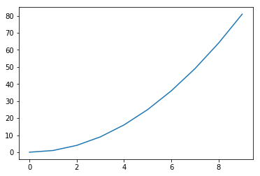

```python
%matplotlib inline
import matplotlib.pyplot as plt

xs = []
for x in range(0, 10):
    xs.append(x)

ys = []
# wir müssen hier eine Schreife schreiben (oder eine list comprehension), um aus der Liste xs die Liste ys zu erzeugen
for x in xs:
    ys.append(x ** 2)

plt.plot(xs, ys)
plt.show()
```

Nun benutzen wir die Array-Datenstruktur aus dem Numpy-Modul:

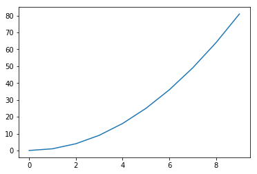

```python
%matplotlib inline
import matplotlib.pyplot as plt

# wir importieren das numpy-Modul; als Abkürzung besteht die Konvention, np zu verwenden
import numpy as np

# wir erzeugen einen Array mit den ganzen Zahlen von 0 bis 9 und speichern es in der Variable xs
xs = np.arange(10)

# auf ein Numpy-Array-Objekt können wir ohne Weiteres elementweise Rechenoperationen anwenden, z.B. jedes Element quadrieren
ys = xs ** 2

plt.plot(xs, ys)
plt.show()
```

```python
type(ys)
```

```
numpy.ndarray
```

### Arrays erzeugen

Mit dem `array()` - Befehl können wir Python-Listen in Arrays umwandeln.

```python
np.array([1, 2, 3, 4, 5, 10])
```

```
array([ 1,  2,  3,  4,  5, 10])
```

Mit der `arange()` - Funktion wird ein Array zu einem beliebigen Zahlenbereich erstellt.

```python
np.arange(1, 11)
```

```
array([ 1,  2,  3,  4,  5,  6,  7,  8,  9, 10])
```

```python
np.arange(10)
```

```
array([0, 1, 2, 3, 4, 5, 6, 7, 8, 9])
```

Es gibt auch einen eigenen Befehl um einen beliebig langen Array zu erzeugen (hier: 10 Elemente), der nur mit Nullen gefüllt ist: die `zeros()`-Funktion.

```python
np.zeros(10)
```

```
array([ 0.,  0.,  0.,  0.,  0.,  0.,  0.,  0.,  0.,  0.])
```

Mit `ones()` gibt es eine entsprechende Funktion auch für Einsen:

```python
np.ones(10)
```

```
array([ 1.,  1.,  1.,  1.,  1.,  1.,  1.,  1.,  1.,  1.])
```

### Mit Arrays rechnen

Rechenoperationen auf einem Array-Objekt werden für jeden Wert des Arrays ausgeführt, ohne dass diese Werte in einer *Schleife* oder *list comprehension* ausdrücklich durchlaufen werden müssen.

```python
np.arange(10) + 3
```

```
array([ 3,  4,  5,  6,  7,  8,  9, 10, 11, 12])
```

```python
np.arange(10) * 3
```

```
array([ 0,  3,  6,  9, 12, 15, 18, 21, 24, 27])
```

Daneben gibt es auch vorgefertigte Methoden für Arrays:

```python
# Mittelwert
print(np.array([1, 2, 3, 4, 5, 10]).mean())

# Minimum
print(np.array([1, 2, 3, 4, 5, 10]).min())

# Maximum
print(np.array([1, 2, 3, 4, 5, 10]).max())

# Standardabweichung
print(np.array([1, 2, 3, 4, 5, 10]).std())
```

```
4.16666666667
1
10
2.91070819943
```